# Activity_Monitoring_Data

Kristine Dreimane

2024-04-03

## Loading and preprocessing the data

*1.Load the data*

```r
#set working directory
library(ggplot2)
setwd("C:/Users/Admin/Desktop/RepData_PeerAssessment1")

#import file

df <- read.csv("activity.csv")
str(data)
```

```
## function (..., list = character(), package = NULL, lib.loc = NULL, verbose = getOption("verbose"),
##     envir = .GlobalEnv, overwrite = TRUE)
```

*2. Process/transform the data (if necessary) into a format suitable for your analysis*

```r
df$date <- as.Date(x=df$date, format = "%Y-%m-%d")
original_data <- df
df<- na.omit(df)
```

## What is mean total number of steps taken per day?

*1. Calculate the total number of steps taken per day*

```r
total_steps_per_day <- aggregate(steps ~ date, data = df, FUN = sum)
```

*2. Make a histogram of the total number of steps taken each day*

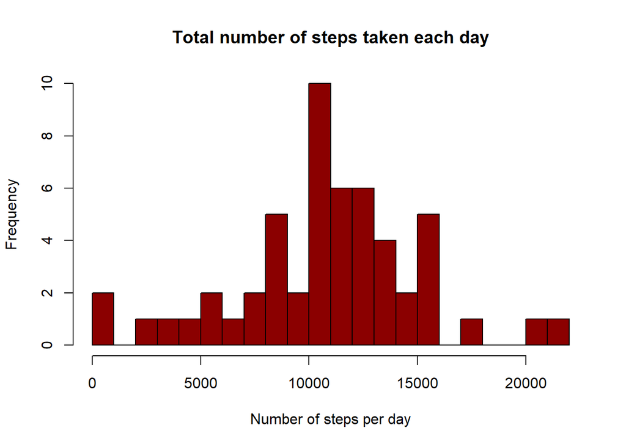

```r
hist(total_steps_per_day$steps,
     main = "Total number of steps taken each day",
     xlab = "Number of steps per day",
     col = "darkred",
     breaks = 30)
```

*3a. Calculate and report the mean of the total number of steps taken per day*

```r
mean_total_numb_of_steps <- mean(total_steps_per_day$steps)
mean_total_numb_of_steps
```

```
## [1] 10766.19
```

*3b. Calculate and report the median of the total number of steps taken per day*

```r
median_total_number_of_steps <- median(total_steps_per_day$steps)
median_total_number_of_steps
```

```
## [1] 10765
```

## What is the average daily activity pattern?

*Make a time series plot of the 5-minute interval (x-axis) and the average number of steps taken, averaged across all days (y-axis)*

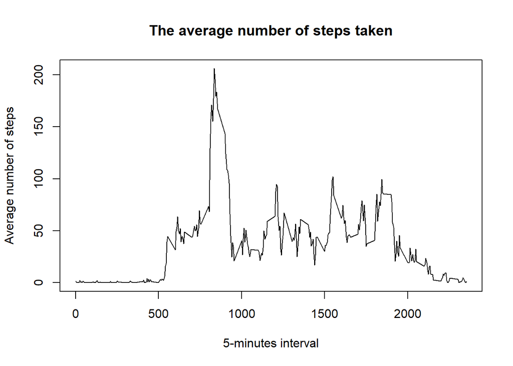

```r
average_steps_per_interval <- aggregate(steps ~ interval, data = df, FUN = mean)
plot(x = average_steps_per_interval$interval,
     y = average_steps_per_interval$steps,
     type = "l",
     col = "black",
     xlab = "5-minutes interval",
     ylab = "Average number of steps",
     main = "The average number of steps taken")
```

*Which 5-minute interval, on average across all the days in the dataset, contains the maximum number of steps?*

```r
five_min_interval <- average_steps_per_interval$interval[which.max(average_steps_per_interval$steps)]
five_min_interval
```

```
## [1] 835
```

## Imputing missing values

*1. Calculate and report the total number of missing values in the dataset (i.e. the total number of rows with NAs)*

```r
without_na <- sum(is.na(original_data$steps))
without_na
```

```
## [1] 2304
```

*2. Fill missing values with mean*

```r
fill_missing_with_median <- aggregate(steps ~ interval, data = original_data, FUN = mean, na.rm = TRUE)
```

*3.Create a new dataset that is equal to the original dataset but with the missing data filled in.*

```r
fillNA_data <- original_data

is_na_steps <- is.na(original_data$steps)
aux <- na.omit(subset(fill_missing_with_median, interval == original_data$interval[is_na_steps]))
fillNA_data$steps[is_na_steps] <- aux[, 2]
na_steps_fillNA <- sum(is.na(fillNA_data))
```

*4.Make a histogram of the total number of steps taken each day.*

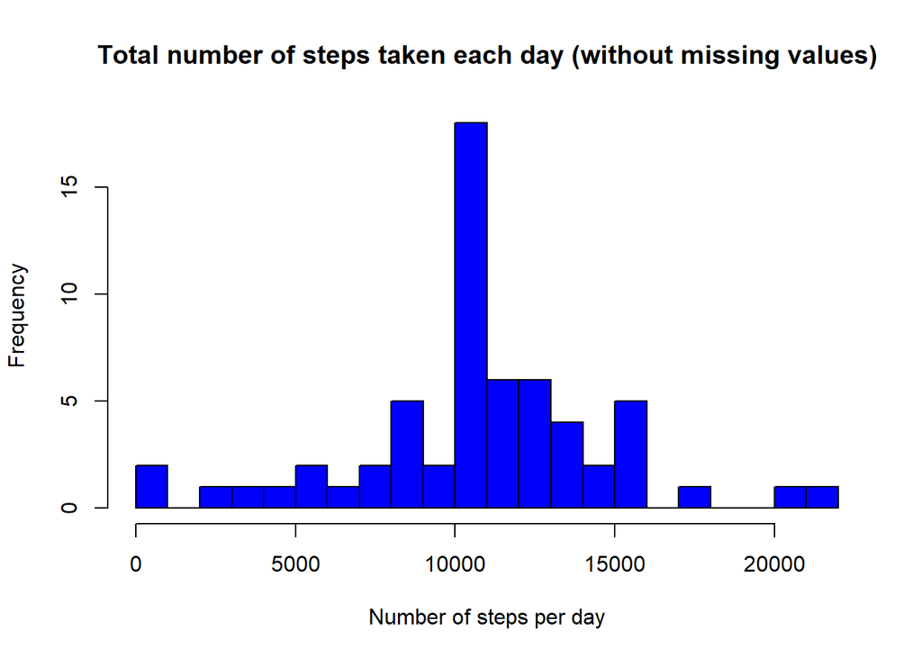

```r
steps_per_day_noNA <- aggregate(steps ~ date, data = fillNA_data, FUN = sum, na.rm = TRUE)
hist(steps_per_day_noNA$steps,
     main = "Total number of steps taken each day (without missing values)",
     xlab = "Number of steps per day",
     col = "blue",
     breaks = 30)
```

*5.Calculate and report the mean and median total number of steps taken per day*

```r
mean_steps_per_day <- mean(steps_per_day_noNA$steps)
mean_steps_per_day
```

```
## [1] 10766.19
```

```r
median_steps_per_day <- median(steps_per_day_noNA$steps)
median_steps_per_day
```

```
## [1] 10766.19
```

```r
summary(total_steps_per_day$steps)
```

```
##    Min. 1st Qu.  Median    Mean 3rd Qu.    Max.
##      41    8841   10765   10766   13294   21194
```

```r
summary(steps_per_day_noNA$steps)
```

```
##    Min. 1st Qu.  Median    Mean 3rd Qu.    Max.
##      41    9819   10766   10766   12811   21194
```

```r
weekdays_values = c('Monday', 'Tuesday', 'Wednesday', 'Thursday', 'Friday')
date_type <- ifelse(
                weekdays(fillNA_data$date) %in% weekdays_values,
                'weekday',
                'weekend')
fillNA_data$day <- factor(x = date_type)
```

*2. Make a plot*

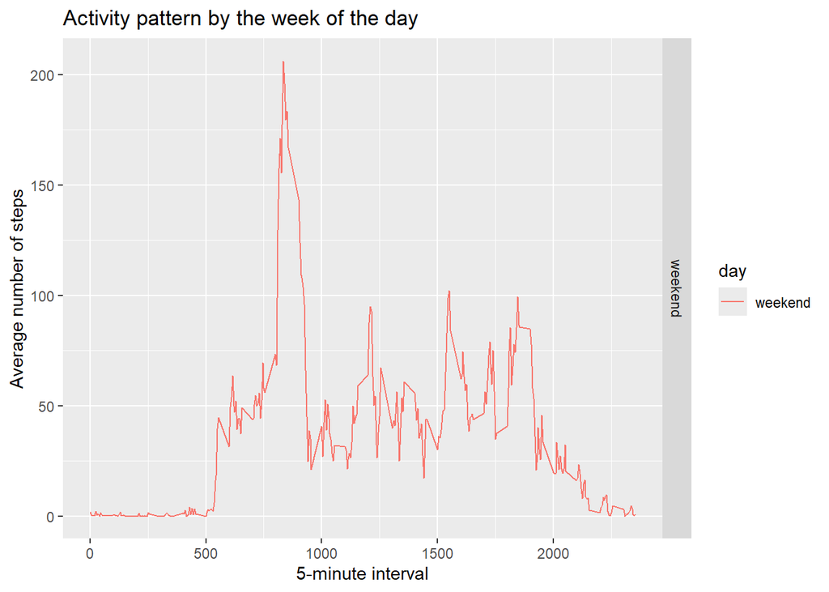

```r
average_steps_per_weekday <- aggregate(steps ~ interval + day, data = fillNA_data, FUN = mean, na.rm = TRUE)

library(ggplot2)
ggplot(average_steps_per_weekday, aes(interval, steps, color = day)) +
       geom_line() +
       facet_grid(day ~ .) +
       xlab('5-minute interval') +
       ylab('Average number of steps') +
       ggtitle('Activity pattern by the week of the day ')
```